# Data analysis: novelty distraction in eye-movements during reading

Martin R. Vasilev

11 März 2019

## Experiment:

Vasilev et al. (2019) found that a 50-ms deviant sound (a burst of white noise) presented at the onset of fixation on a target word led to significantly longer fixation durations compared to a 50-ms standard sound (a sine wave). The results suggested that increase in fixation durations was not due to an interference with the lexical processing of the target word, but likely due to inhibition of the programming of the next saccade.

2 x 2 design with **sound** (standard vs novel) and **sound onset delay** (0 vs 120 ms) as within-subject factors. Participants were 64 undergraduate students.

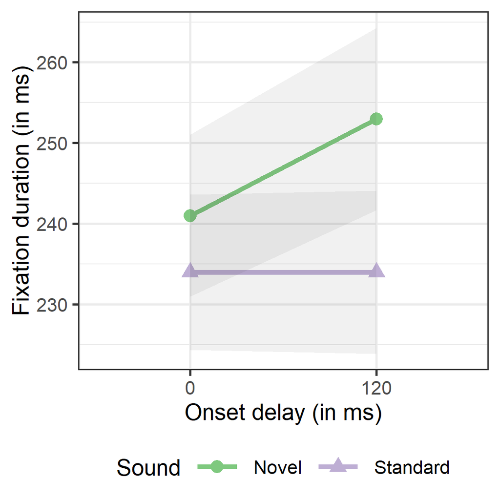

*Figure 1*. Duration of the first fixation during which the sound is first played.

*Table 1*. Descriptive statistics of the first fixation during which the sound is played (same data as Fig. 1)

|  | Sound | Delay | Mean | SD | SE |
| --- | --- | --- | --- | --- | --- |
| 1 | Novel | 0 | 241 | 80.20746 | 10.025932 |
| 3 | Standard | 0 | 234 | 76.88956 | 9.611195 |
| 2 | Novel | 120 | 253 | 90.36590 | 11.295738 |
| 4 | Standard | 120 | 234 | 80.89537 | 10.111921 |

Table 2.*LMM Results of the First Fixation Duration during which the Sound is Played*

|  | Estimate | Std. Error | t value |
| --- | --- | --- | --- |
| Intercept | 5.440 | 0.015 | 357.483 |
| Sound (Novel vs STD) | -0.032 | 0.011 | -2.871 |
| Delay (120 vs 0ms) | 0.038 | 0.012 | 3.273 |
| Sound x Delay | -0.040 | 0.015 | -2.614 |

*Note*: t-values greater than 1.96 indicate a significant result.